# 2.2 Decision Trees and Random Forests

## Decision Trees and Random Forests

Please reference the video lecture for an overview of Decision Trees and Random Forests. This is just a reference notebook for the lecture video’s code.

## Growing a Decision Tree

You may need to install the rpart library. you can find a lot more information about this library here.

```r
library(rpart)
```

## Sample Data

We’ll use the kyphosis data frame which has 81 rows and 4 columns. representing data on children who have had corrective spinal surgery. It has the following columns:

Kyphosis-a factor with levels absent present indicating if a kyphosis (a type of deformation) was present after the operation.

Age-in months

Number-the number of vertebrae involved

Start-the number of the first (topmost) vertebra operated on.

Let’s check out the structure:

```r
str(kyphosis)
```

```
## 'data.frame':    81 obs. of  4 variables:
##  $ Kyphosis: Factor w/ 2 levels "absent","present": 1 1 2 1 1 1 1 1 1 2 ...
##  $ Age     : int  71 158 128 2 1 1 61 37 113 59 ...
##  $ Number  : int  3 3 4 5 4 2 2 3 2 6 ...
##  $ Start   : int  5 14 5 1 15 16 17 16 16 12 ...
```

```r
head(kyphosis)
```

```
##   Kyphosis Age Number Start
## 1   absent  71      3     5
## 2   absent 158      3    14
## 3  present 128      4     5
## 4   absent   2      5     1
## 5   absent   1      4    15
## 6   absent   1      2    16
```

```r
tree <- rpart(Kyphosis ~ . , method='class', data= kyphosis)
```

## Examining Results of the Tree Model

```r
printcp(tree)
```

```
##
## Classification tree:
## rpart(formula = Kyphosis ~ ., data = kyphosis, method = "class")
##
## Variables actually used in tree construction:
## [1] Age   Start
##
## Root node error: 17/81 = 0.20988
##
## n= 81
##
##         CP nsplit rel error xerror    xstd
## 1 0.176471      0   1.00000 1.0000 0.21559
## 2 0.019608      1   0.82353 1.0588 0.22010
## 3 0.010000      4   0.76471 1.0588 0.22010
```

## Tree Visualization

There are some built-in visualization capabilities from the table above, but they aren’t very good looking:

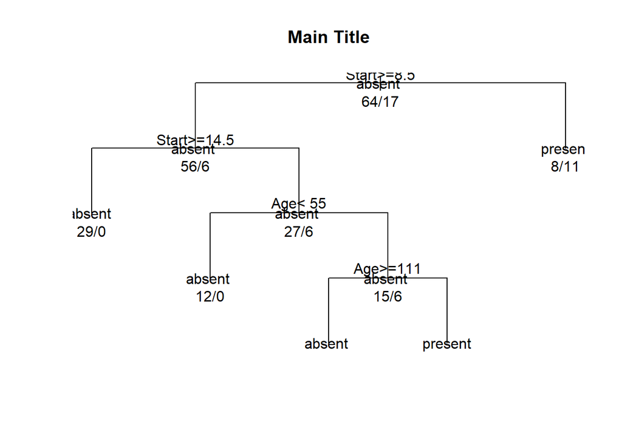

```r
plot(tree, uniform=TRUE, main="Main Title")
text(tree, use.n=TRUE, all=TRUE)
```

The rpart.plot library package makes these visualizations much better.

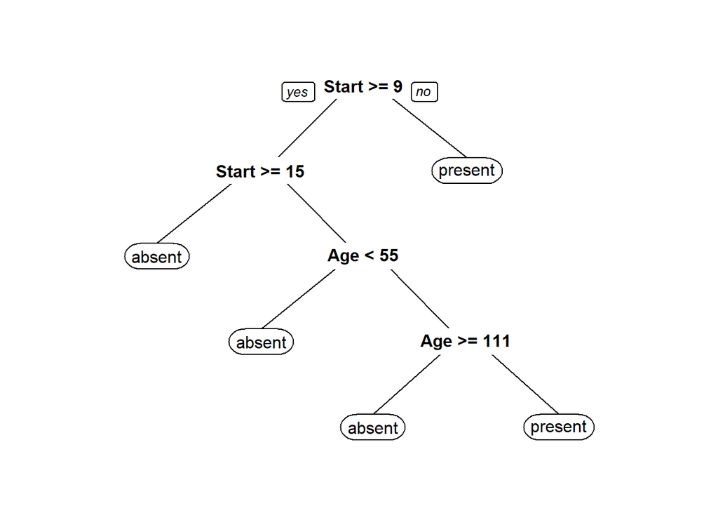

```r
library(rpart.plot)
prp(tree)
```

## Random Forests

Random forests improve predictive accuracy by generating a large number of bootstrapped trees (based on random samples of variables), classifying a case using each tree in this new “forest”, and deciding a final predicted outcome by combining the results across all of the trees (an average in regression, a majority vote in classification).

We can use the randomForest library to create and build out a Random Forest:

```r
library(randomForest)
model <- randomForest(Kyphosis ~ .,   data=kyphosis)
print(model)
```

```
##
## Call:
##  randomForest(formula = Kyphosis ~ ., data = kyphosis)
##                Type of random forest: classification
##                      Number of trees: 500
## No. of variables tried at each split: 1
##
##         OOB estimate of  error rate: 19.75%
## Confusion matrix:
##         absent present class.error
## absent      60       4   0.0625000
## present     12       5   0.7058824
```

```r
importance(model)
```

```
##        MeanDecreaseGini
## Age            8.565725
## Number         5.323428
## Start         10.022358
```

## Conclusion

You should be beginning to feel very comfortable with the syntax for training a model on data. The key is to just understand the background of the algorithm being used and know what library to install and use for the specific algorithm being used.